# Photometric Redshift with CosmoPhotoz

This is short tutorial explaining how to perform photometric redshift estimation using the CosmoPhotoz R package.

# Required libraries

```r
require(CosmoPhotoz)
require(ggplot2)
```

Load the PHAT0 data included in the package. Here we are using 5% of all dataset for training.

```r
data(PHAT0train)

data(PHAT0test)
```

```r
PC_comb<-computeCombPCA(subset(PHAT0train,select=c(-redshift)),
                       subset(PHAT0test,select=c(-redshift)))
```

Number of variance explained by each PC

```r
PC_comb$PCsum
```

```
## Importance of components:
##                          [,1]   [,2]    [,3]     [,4]     [,5]     [,6]
## Standard deviation     2.7493 1.4345 0.59802 0.301797 0.150761 0.140713
## Proportion of Variance 0.7454 0.2029 0.03527 0.008982 0.002241 0.001953
## Cumulative Proportion  0.7454 0.9483 0.98359 0.992570 0.994812 0.996764
##                            [,7]     [,8]      [,9]     [,10]
## Standard deviation     0.132399 0.082982 0.0786826 0.0469798
## Proportion of Variance 0.001729 0.000679 0.0006105 0.0002176
## Cumulative Proportion  0.998493 0.999172 0.9997824 1.0000000
```

Add the redshift column to the PCA projections of the Training sample

```r
Trainpc<-cbind(PC_comb$x,redshift=PHAT0train$redshift)
```

Train the glm model using Gamma Family. 6 PCs explain 99.5% of data variance. In order to account for small variations in the shape, we include a polynomial term for the 2 first PCs (95% of data variance)

```r
Fit<-glmTrainPhotoZ(Trainpc,formula=redshift~poly(Comp.1,2)*poly(Comp.2,2)*Comp.3*Comp.4*Comp.5*Comp.6,method="Bayesian",family="gamma")
```

Compute basic diagnostic statistics

```
## $mean
## [1] 0.001229
##
## $sd
## [1] 0.03868
##
## $median
## [1] 0.0005198
##
## $mad
## [1] 0.01791
##
## $rmse
## [1] 0.04858
##
## $outliers
## [1] "0.08%"
```

Create basic diagnostic plots

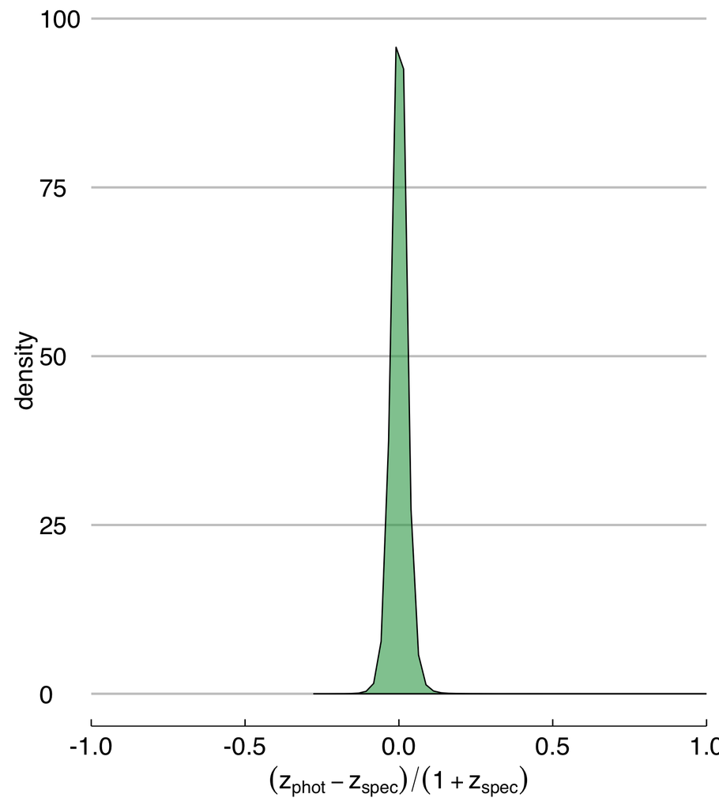

```r
plotDiagPhotoZ(photoz, specz, type = "errordist")
```

```r
datashow<-sample(length(photoz),15000)
```

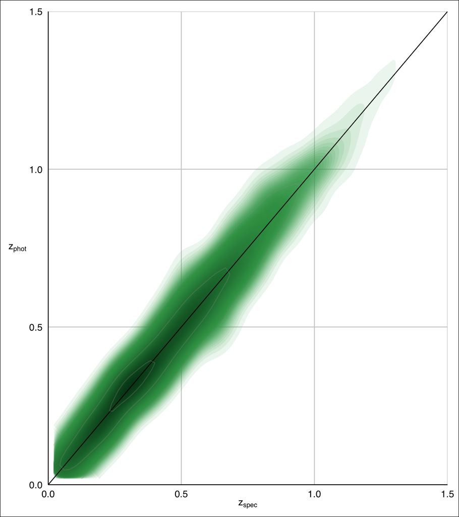

```r
plotDiagPhotoZ(photoz[datashow], specz[datashow], type = "predobs")+coord_cartesian(xlim =c(0,1.5), ylim = c(0,1.5))
```

Scatter distribution as a function of redshift, violin plot

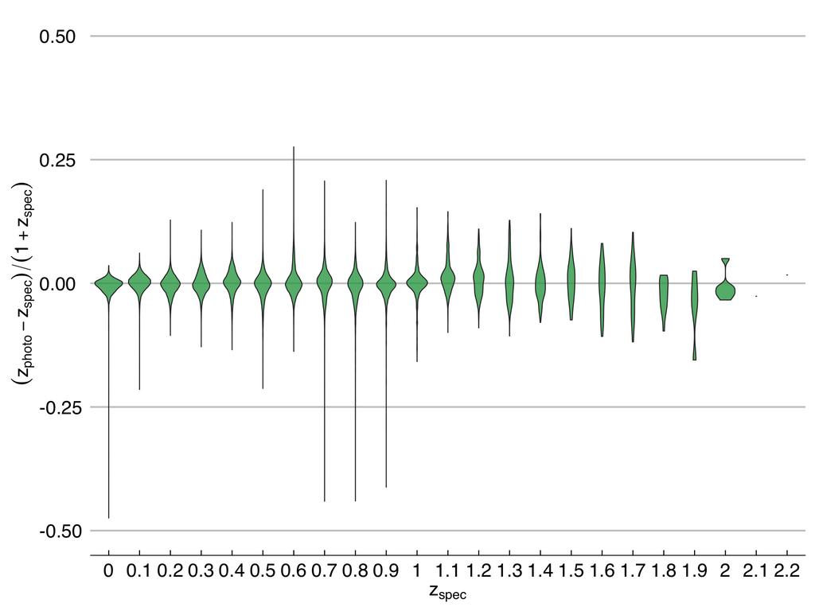

```r
plotDiagPhotoZ(photoz, specz, type = "errorviolins")
```

Scatter distribution as a function of redshift, box plot

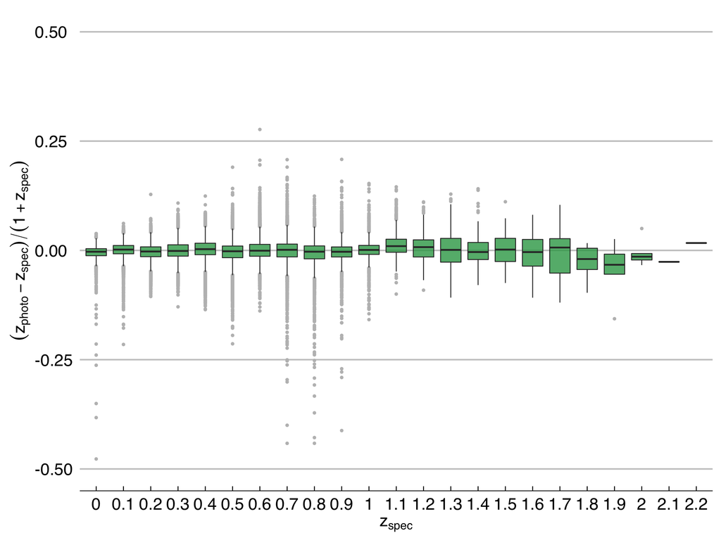

```r
plotDiagPhotoZ(photoz, specz, type = "box")
```